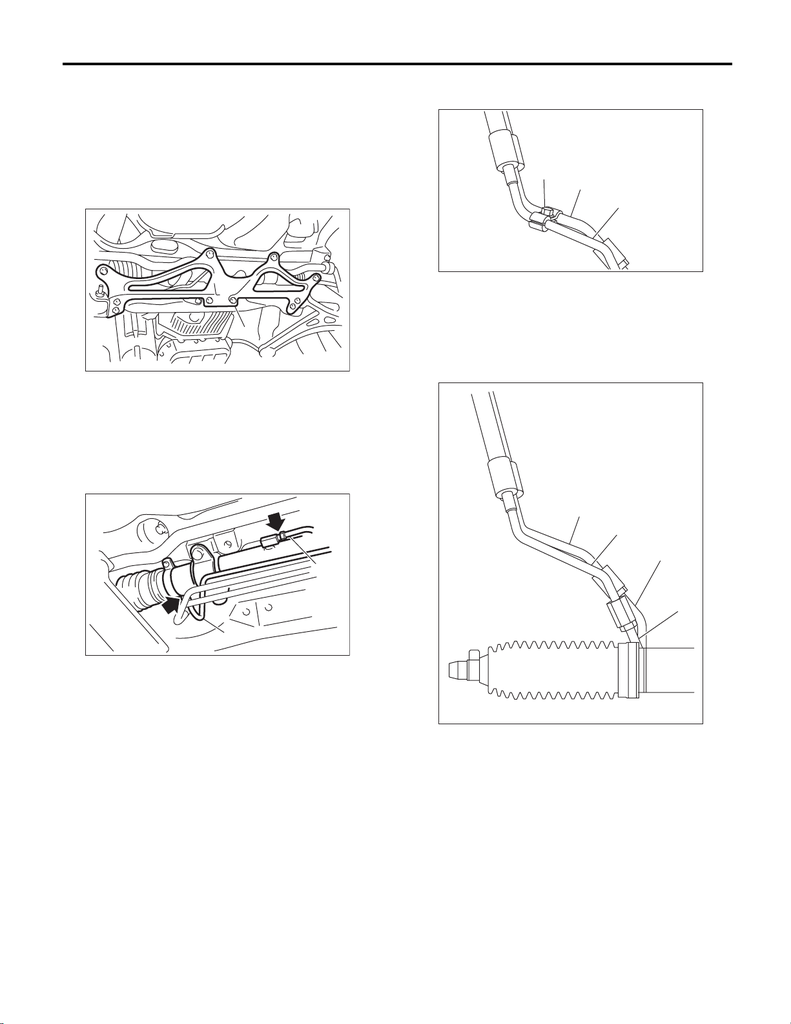

PS-70

Pipe Assembly

POWER ASSISTED SYSTEM (POWER STEERING)

8. Pipe Assembly

A: REMOVAL

1) Disconnect the ground cable from battery.

2) Remove the under cover. <Ref. to EI-21, RE-

MOVAL, Front Under Cover.>

3) Lift up the vehicle, and remove the front cross-

member support plate.

4) Remove the one pipe joint at the center of the

gearbox, and connect the vinyl hose to the pipe and

the joint. Discharge the fluid by turning the steering

wheel fully clockwise and counterclockwise. Dis-

charge the fluid similarly from other pipes.

5) Remove the clamp E from return hose and pres-

sure hose.

6) Disconnect the return hose from return pipe and

disconnect the pressure hose from feed pipe.

7) Remove the air intake duct. <Ref. to IN(STI)-11,

REMOVAL, Air Intake Duct.>

(1) Front crossmember support plate

(1) Pipe A

(2) Pipe B

PS-00445

(1)

(2)

PS-00553

(1)

(1) Pressure hose

(2) Return hose

(3) Clamp E

(1) Feed pipe

(2) Return pipe

(3) Pressure hose

(4) Return hose

PS-00537

(3)

(1)

(2)

PS-00538

(4)

(3)

(2)

(1)

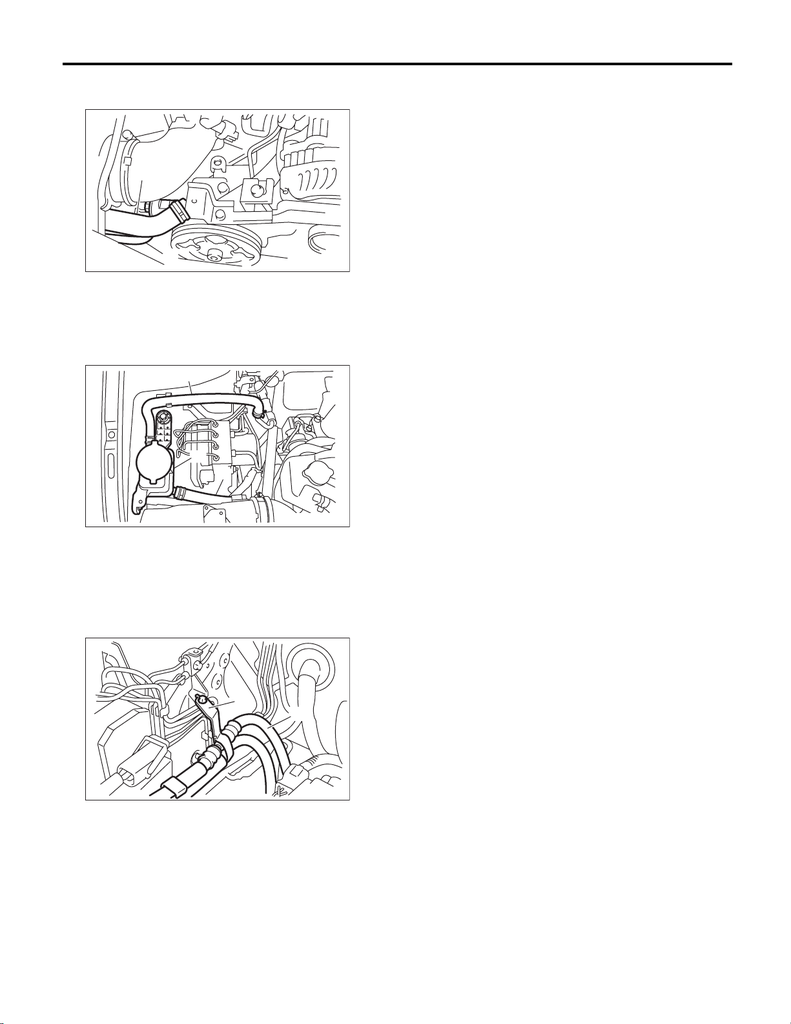

PS-71

Pipe Assembly

POWER ASSISTED SYSTEM (POWER STEERING)

8) Disconnect the suction hose and pressure hose

from oil pump.

9) Disconnect the suction hose and return hose

from the reservoir tank.

10) Remove the hose bracket and take out the

hose assembly from vehicle.

(1) Suction hose

(2) Pressure hose

(1) Reservoir tank

(2) Suction hose

(3) Return hose

(1) Hose ASSY

(2) Hose bracket

PS-00459

(2)

(1)

PS-00799

(3)

(1)

(2)

PS-00624

(2)

(1)

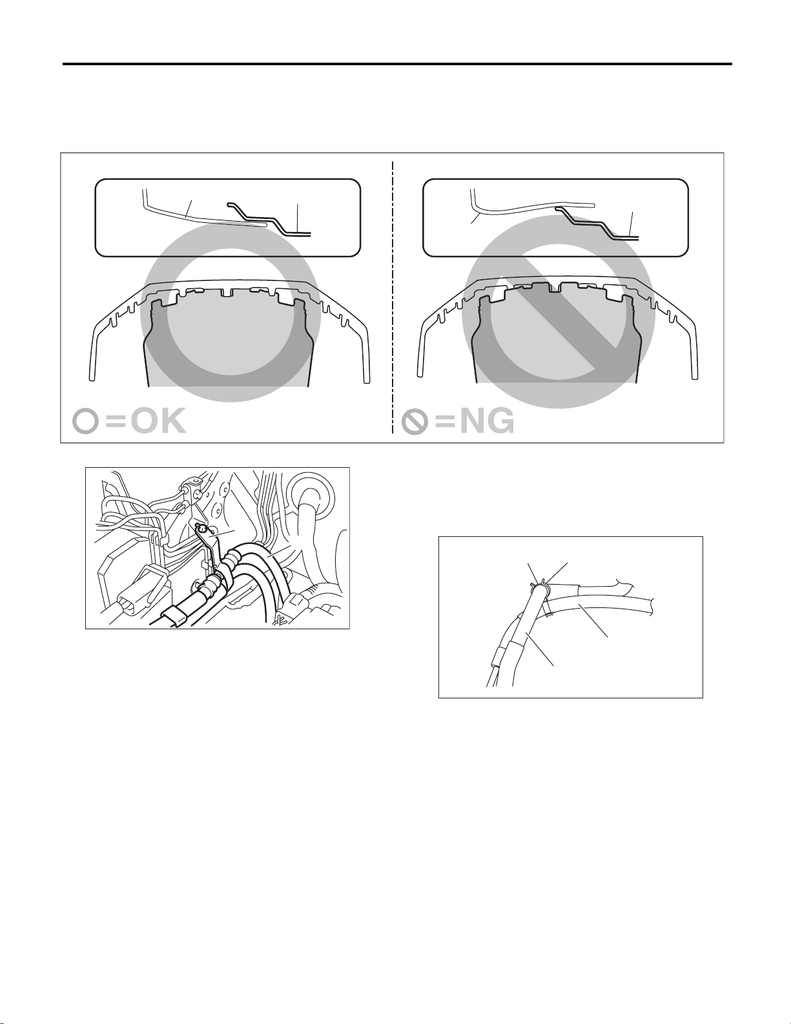

PS-72

Pipe Assembly

POWER ASSISTED SYSTEM (POWER STEERING)

B: INSTALLATION

CAUTION:

Install the under cover - front so that the front end of the under cover (b) comes inside the bumper

face - front (a).

1) Temporarily tighten the hose bracket bolt. 2) Install the plastic clip to the pressure hose and

suction hose.

CAUTION:

Align the installation position of the plastic clip

with the protector edge of the suction hose.

EI-04291

(b)

(a)

(b)

(a)

(1) Hose ASSY

(2) Hose bracket

PS-00624

(2)

(1)

(1) Plastic clip

(2) Protector

(3) Suction hose

(4) Pressure hose

PS-00456

(1)

(2)

(3)

(4)

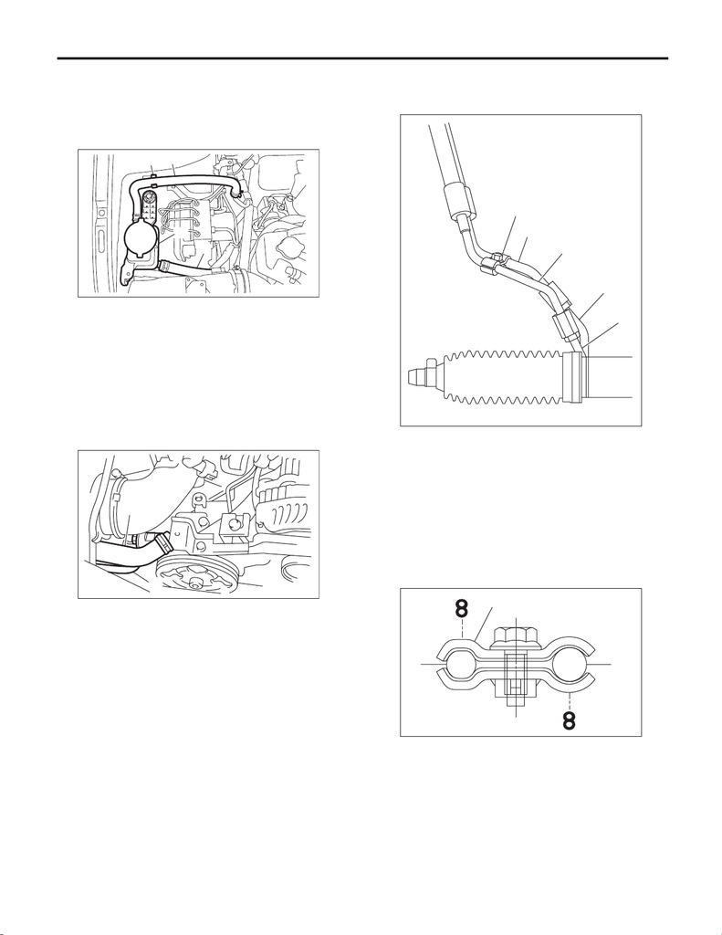

PS-73

Pipe Assembly

POWER ASSISTED SYSTEM (POWER STEERING)

3) Connect the suction hose and return hose to the

reservoir tank.

CAUTION:

Firmly insert the plastic clip of return hose to

the bracket.

4) Connect the suction hose and pressure hose to

the oil pump. Tighten the eyebolt of pressure hose.

Tightening torque:

40 N·m (4.1 kgf-m, 29.5 ft-lb)

5) Temporarily connect the pressure hose to feed

pipe and return hose to return pipe. Temporarily

tighten the bolt of clamp E.

NOTE:

Make sure that the character “8” on each clamp is

positioned on the opposite side, as shown in the

figure.

(1) Reservoir tank

(2) Suction hose

(3) Return hose

(4) Plastic clip

(1) Suction hose

(2) Pressure hose

PS-01212

(3)

(1)

(2)

(4)

PS-00459

(2)

(1)

(1) Return hose

(2) Pressure hose

(3) Clamp E

(4) Return pipe

(5) Feed pipe

(1) Clamp E

(2) Pressure hose

(3) Return hose

PS-00847

(3)

(2)

(4)

(5)

(1)

PS-01344

(2)

(1)

(3)

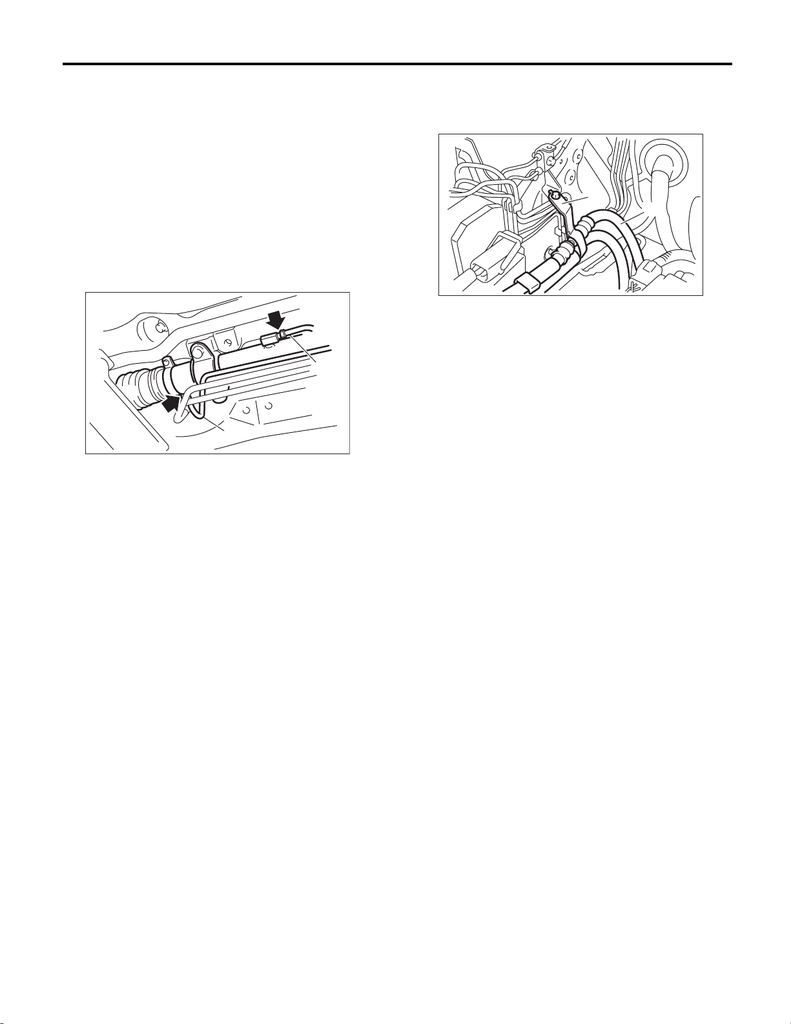

PS-74

Pipe Assembly

POWER ASSISTED SYSTEM (POWER STEERING)

6) Tighten clamp E.

Tightening torque:

7.5 N·m (0.8 kgf-m, 5.5 ft-lb)

7) Tighten the pressure hose to feed pipe and re-

turn hose to return pipe.

Tightening torque:

15 N·m (1.5 kgf-m, 11.1 ft-lb)

8) Connect pipes A and B to the four pipe joints of

the gearbox.

Tightening torque:

Cylinder side: 27 N·m (2.8 kgf-m, 19.9 ft-lb)

Gear housing side: 17 N·m (1.7 kgf-m, 12.5 ft-lb)

9) Install the front crossmember support plate and

jack-up plate.

10) Install the under cover. <Ref. to EI-22, INSTAL-

LATION, Front Under Cover.>

11) Lower the vehicle.

12) Tighten the bolts which hold the hose bracket.

Tightening torque:

10 N·m (1.0 kgf-m, 7.4 ft-lb)

13) Install the air intake duct. <Ref. to IN(STI)-11,

INSTALLATION, Air Intake Duct.>

14) Connect the battery ground terminal.

15) Fill with the specified fluid.

CAUTION:

Never start the engine before filling with fluid;

otherwise the vane pump may become seized.

16) Finally, check the clearance between pipes or

hoses as shown in the figure indicated in “General

Diagnostic Table”. <Ref. to PS-94, CLEARANCE

CHECK (HYDRAULIC TYPE), INSPECTION, Gen-

eral Diagnostic Table.>

(1) Pipe A

(2) Pipe B

(2)

PS-00553

(1)

(1) Hose ASSY

(2) Hose bracket

PS-00624

(2)

(1)

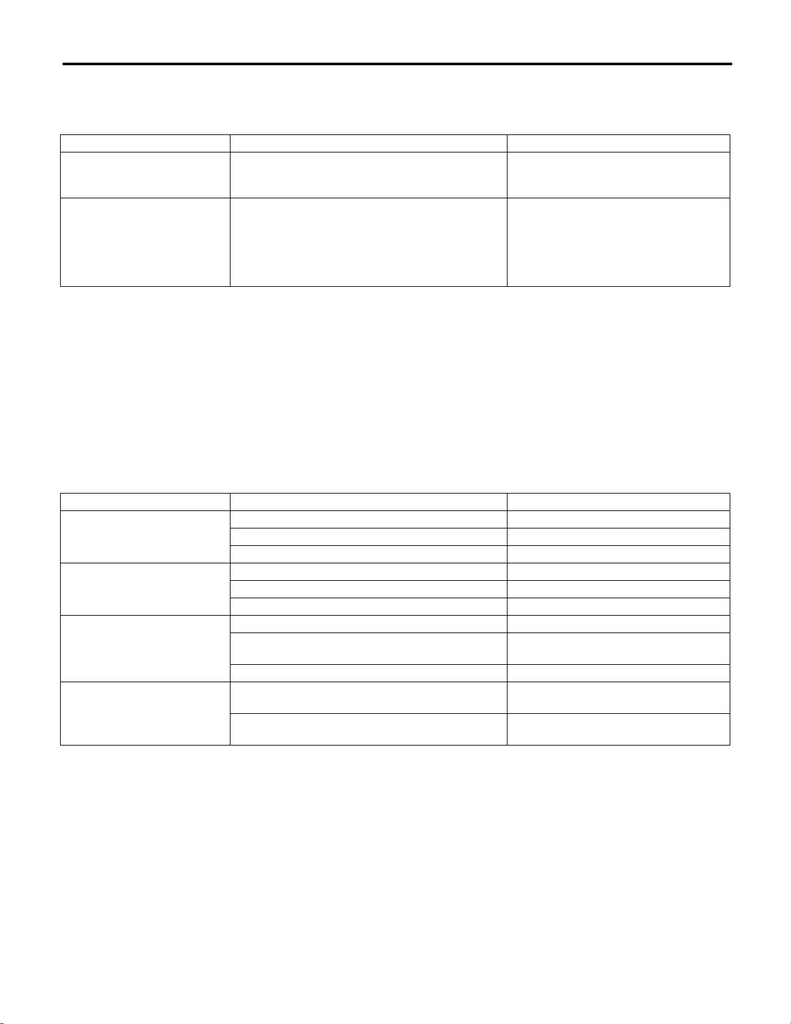

PS-75

Pipe Assembly

POWER ASSISTED SYSTEM (POWER STEERING)

C: INSPECTION

Check all disassembled parts for wear, damage or other problems. Repair or replace the defective parts as

necessary.

CAUTION:

Although the surface layer materials of rubber hoses have excellent weathering resistance, heat re-

sistance and resistance for low temperature brittleness, they are likely to be damaged chemically by

brake fluid, battery electrolyte, engine oil and automatic transmission fluid and their service lives are

to be very shortened. Wipe off hoses immediately if any of these come into contact with the hoses.

Since resistances for heat or low temperature brittleness are gradually declining according to time

accumulation of hot or cold conditions for the hoses and their service lives are shortening accord-

ingly, it is necessary to perform careful inspection frequently when the vehicle is used in hot weather

areas, cold weather areas and a driving condition in which many steering operations are required in

short time.

Continuous discharge of the relief valve for 5 seconds or more will reduce the service lives of hoses,

oil pump, fluid, etc., due to over heating.

Part Maintenance parts Corrective action

Pipe

• O-ring fitting surface damage

• Nut damage

• Pipe damage

Replace with a new part.

Hose

• Flare surface damage

• Flare nut damage

• Outer surface cracks

• Outer surface wear

• Clip damage

• End coupling or adapter deformation

Replace with a new part.

Trouble Possible cause Corrective action

Pressure hose burst

Excessive holding time of relief status Instruct customers.

Malfunction of the relief valve Replace the oil pump.

Poor cold characteristic of fluid Replace fluid.

Disconnection of the return

hose

Improper connection Repair.

Loosening of the clip Replace the hose and clip.

Poor cold characteristic of fluid Replace fluid.

Fluid slightly leaking out of

hose

Wrong layout, tensioned Replace the hose.

Excessive play of engine due to deterioration of

engine mounting rubber

Replace the parts if defective.

Improper stop position of pitching stopper Replace the parts if defective.

Crack on hose

Excessive holding time of relief status

Replace.

Instruct customers.

Power steering fluid, engine oil, electrolyte adhere

on the hose surface

Replace.

Be careful during service work.

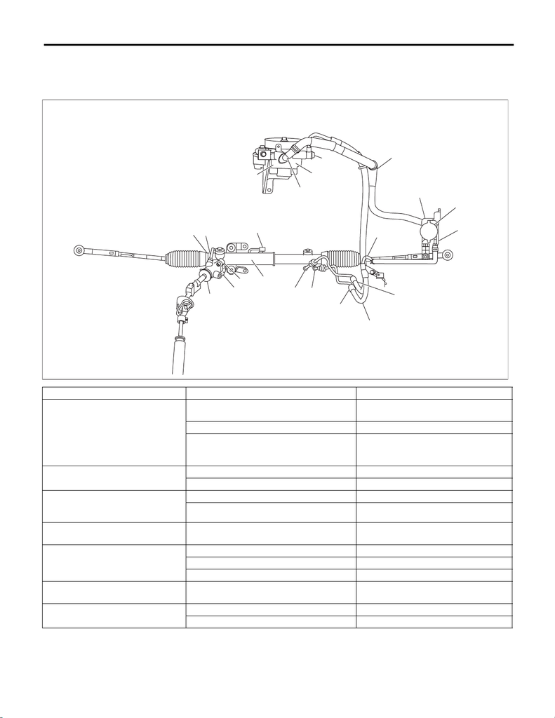

PS-76

Pipe Assembly

POWER ASSISTED SYSTEM (POWER STEERING)

NOTE:

There are conditions in which a fluid leak is diagnosed, but is not actually leaking. This is because the fluid

spilt during the last maintenance was not completely wiped off. Be sure to wipe off spilt fluid thoroughly after

maintenance.

Fluid leaking area Possible cause Corrective action

Leakage from the connections of

pipes and hoses, numbered (1)

through (8) in the figure

Insufficient tightening of flare nut, adhesion of

dirt, damage to flare or flare nut or eyebolt

Loosen and retighten. Replace if ineffec-

tive.

Improper installation of hose or clamp Replace.

Damaged O-ring or gasket

Replace the O-ring, gasket pipe or hose

with new part, if still no improvement,

replace the gearbox or oil pump as well.

Leakage from hose (9) through (13) in

the figure

Crack or damage in hose Replace with a new part.

Crack or damage in hose hardware Replace with a new part.

Leakage from surrounding of alumi-

num portion of oil pump, (14) and (15)

in the figure

Damaged O-ring Replace the oil pump.

Damaged gasket Replace the oil pump.

Leakage from oil tank, (16) and (17) in

the figure

Crack in oil tank Replace the oil tank.

Leakage from filler neck of (18)

Damaged cap packing Replace the cap.

Crack in root of filler neck Replace the oil tank.

Fluid level too high Adjust the fluid level.

Leakage from power cylinder of gear-

box area (19) in the figure

Damaged oil seal Replace the oil seal.

Leakage from (20), (21) in the figure

and control valve of gearbox

Damaged packing or oil seal Replace the faulty parts.

Damage in control valve Replace the control valve.

(10)

(17)

(1)

(13)

(19)

(4)

(2)

(9)

(12)

(16)

(18)

(5)

(6)

(20)

(3)

(21)

PS-00883

(11)

(7)

(14)

(15)

(8)